# Logistic Regression Homework

# Load Libraries & Data

```r
library(caret)
```

```r
juice <- read_csv("logistic_regression/data/orange_juice.csv") %>%  clean_names()
```

```r
glimpse(juice)
```

```
Rows: 1,070
Columns: 18
$ purchase        <chr> "CH", "CH", "CH", "MM", "CH", "CH", "CH", "CH", "CH", "CH", "CH", "CH", "CH", "CH", "CH", "CH", "MM", "MM", "MM",…
$ weekof_purchase <dbl> 237, 239, 245, 227, 228, 230, 232, 234, 235, 238, 240, 263, 276, 268, 278, 278, 240, 268, 269, 254, 257, 258, 259…
$ store_id        <dbl> 1, 1, 1, 1, 7, 7, 7, 7, 7, 7, 7, 7, 7, 7, 7, 7, 1, 2, 2, 7, 7, 1, 7, 7, 7, 7, 7, 7, 7, 7, 2, 7, 2, 2, 3, 3, 1, 1,…
$ price_ch        <dbl> 1.75, 1.75, 1.86, 1.69, 1.69, 1.69, 1.69, 1.75, 1.75, 1.75, 1.86, 1.86, 1.99, 1.86, 2.06, 2.06, 1.75, 1.86, 1.86,…
$ price_mm        <dbl> 1.99, 1.99, 2.09, 1.69, 1.69, 1.99, 1.99, 1.99, 1.99, 1.99, 2.09, 2.13, 2.13, 2.13, 2.13, 2.13, 1.99, 2.18, 2.18,…
$ disc_ch         <dbl> 0.00, 0.00, 0.17, 0.00, 0.00, 0.00, 0.00, 0.00, 0.00, 0.00, 0.00, 0.27, 0.00, 0.00, 0.00, 0.00, 0.00, 0.00, 0.00,…
$ disc_mm         <dbl> 0.00, 0.30, 0.00, 0.00, 0.00, 0.00, 0.40, 0.40, 0.40, 0.40, 0.00, 0.00, 0.54, 0.00, 0.00, 0.00, 0.30, 0.00, 0.00,…
$ special_ch      <dbl> 0, 0, 0, 0, 0, 0, 1, 1, 0, 0, 0, 0, 0, 0, 0, 0, 0, 0, 0, 0, 0, 0, 0, 1, 0, 1, 0, 0, 1, 0, 0, 1, 0, 1, 0, 0, 0, 0,…
$ special_mm      <dbl> 0, 1, 0, 0, 0, 1, 1, 0, 0, 0, 0, 0, 1, 0, 0, 0, 1, 1, 0, 0, 0, 0, 0, 0, 0, 0, 0, 0, 0, 0, 0, 0, 1, 0, 0, 0, 0, 0,…
$ loyal_ch        <dbl> 0.500000, 0.600000, 0.680000, 0.400000, 0.956535, 0.965228, 0.972182, 0.977746, 0.982197, 0.985757, 0.988606, 0.9…
$ sale_price_mm   <dbl> 1.99, 1.69, 2.09, 1.69, 1.69, 1.99, 1.59, 1.59, 1.59, 1.59, 2.09, 2.13, 1.59, 2.13, 2.13, 2.13, 1.69, 2.18, 2.18,…
$ sale_price_ch   <dbl> 1.75, 1.75, 1.69, 1.69, 1.69, 1.69, 1.69, 1.75, 1.75, 1.75, 1.86, 1.59, 1.99, 1.86, 2.06, 2.06, 1.75, 1.86, 1.86,…
$ price_diff      <dbl> 0.24, -0.06, 0.40, 0.00, 0.00, 0.30, -0.10, -0.16, -0.16, -0.16, 0.23, 0.54, -0.40, 0.27, 0.07, 0.07, -0.06, 0.32…
$ store7          <chr> "No", "No", "No", "No", "Yes", "Yes", "Yes", "Yes", "Yes", "Yes", "Yes", "Yes", "Yes", "Yes", "Yes", "Yes", "No",…
$ pct_disc_mm     <dbl> 0.000000, 0.150754, 0.000000, 0.000000, 0.000000, 0.000000, 0.201005, 0.201005, 0.201005, 0.201005, 0.000000, 0.0…
$ pct_disc_ch     <dbl> 0.000000, 0.000000, 0.091398, 0.000000, 0.000000, 0.000000, 0.000000, 0.000000, 0.000000, 0.000000, 0.000000, 0.1…
$ list_price_diff <dbl> 0.24, 0.24, 0.23, 0.00, 0.00, 0.30, 0.30, 0.24, 0.24, 0.24, 0.23, 0.27, 0.14, 0.27, 0.07, 0.07, 0.24, 0.32, 0.32,…
$ store           <dbl> 1, 1, 1, 1, 0, 0, 0, 0, 0, 0, 0, 0, 0, 0, 0, 0, 1, 2, 2, 0, 0, 1, 0, 0, 0, 0, 0, 0, 0, 0, 2, 0, 2, 2, 3, 3, 1, 1,…
```

```r
summary(juice) # no NA values
```

```
   purchase         weekof_purchase    store_id       price_ch        price_mm        disc_ch           disc_mm         special_ch
 Length:1070        Min.   :227.0   Min.   :1.00   Min.   :1.690   Min.   :1.690   Min.   :0.00000   Min.   :0.0000   Min.   :0.0000
 Class :character   1st Qu.:240.0   1st Qu.:2.00   1st Qu.:1.790   1st Qu.:1.990   1st Qu.:0.00000   1st Qu.:0.0000   1st Qu.:0.0000
 Mode  :character   Median :257.0   Median :3.00   Median :1.860   Median :2.090   Median :0.00000   Median :0.0000   Median :0.0000
                    Mean   :254.4   Mean   :3.96   Mean   :1.867   Mean   :2.085   Mean   :0.05186   Mean   :0.1234   Mean   :0.1477
                    3rd Qu.:268.0   3rd Qu.:7.00   3rd Qu.:1.990   3rd Qu.:2.180   3rd Qu.:0.00000   3rd Qu.:0.2300   3rd Qu.:0.0000
                    Max.   :278.0   Max.   :7.00   Max.   :2.090   Max.   :2.290   Max.   :0.50000   Max.   :0.8000   Max.   :1.0000
   special_mm        loyal_ch        sale_price_mm   sale_price_ch     price_diff         store7           pct_disc_mm
 Min.   :0.0000   Min.   :0.000011   Min.   :1.190   Min.   :1.390   Min.   :-0.6700   Length:1070        Min.   :0.0000
 1st Qu.:0.0000   1st Qu.:0.325257   1st Qu.:1.690   1st Qu.:1.750   1st Qu.: 0.0000   Class :character   1st Qu.:0.0000
 Median :0.0000   Median :0.600000   Median :2.090   Median :1.860   Median : 0.2300   Mode  :character   Median :0.0000
 Mean   :0.1617   Mean   :0.565782   Mean   :1.962   Mean   :1.816   Mean   : 0.1465                      Mean   :0.0593
 3rd Qu.:0.0000   3rd Qu.:0.850873   3rd Qu.:2.130   3rd Qu.:1.890   3rd Qu.: 0.3200                      3rd Qu.:0.1127
 Max.   :1.0000   Max.   :0.999947   Max.   :2.290   Max.   :2.090   Max.   : 0.6400                      Max.   :0.4020
  pct_disc_ch      list_price_diff     store
 Min.   :0.00000   Min.   :0.000   Min.   :0.000
 1st Qu.:0.00000   1st Qu.:0.140   1st Qu.:0.000
 Median :0.00000   Median :0.240   Median :2.000
 Mean   :0.02731   Mean   :0.218   Mean   :1.631
 3rd Qu.:0.00000   3rd Qu.:0.300   3rd Qu.:3.000
 Max.   :0.25269   Max.   :0.440   Max.   :4.000
```

## Cleaning

**change purchase into a logical variable, with `false`/`0` representing Citrus Hill (CH) and `true`/`1` representing Minute Maid (MM)**

```r
# check that there is no NA or other values in purchase col
juice %>%
  distinct(purchase)
```

| purchase |
| --- |
| CH |
| MM |

```r
# change CH to 0 and MM to 1, then convert to logical so 0 is false and 1 is true
(juice_clean <- juice %>%
  mutate(purchase = if_else(purchase == "CH", 0, 1),
         purchase = as.logical(purchase))
)
```

| purchase | weekof_purchase | store_id | price_ch | price_mm | disc_ch | disc_mm | special_ch | special_mm | loyal_ch | sale_price_mm | sale_price_ch | price_diff | store7 | pct_disc_mm | pct_disc_ch | list_price_diff | store |
| --- | --- | --- | --- | --- | --- | --- | --- | --- | --- | --- | --- | --- | --- | --- | --- | --- | --- |
| FALSE | 237 | 1 | 1.75 | 1.99 | 0.00 | 0.00 | 0 | 0 | 0.500000 | 1.99 | 1.75 | 0.24 | No | 0.000000 | 0.000000 | 0.24 | 1 |
| FALSE | 239 | 1 | 1.75 | 1.99 | 0.00 | 0.30 | 0 | 1 | 0.600000 | 1.69 | 1.75 | -0.06 | No | 0.150754 | 0.000000 | 0.24 | 1 |
| FALSE | 245 | 1 | 1.86 | 2.09 | 0.17 | 0.00 | 0 | 0 | 0.680000 | 2.09 | 1.69 | 0.40 | No | 0.000000 | 0.091398 | 0.23 | 1 |
| TRUE | 227 | 1 | 1.69 | 1.69 | 0.00 | 0.00 | 0 | 0 | 0.400000 | 1.69 | 1.69 | 0.00 | No | 0.000000 | 0.000000 | 0.00 | 1 |
| FALSE | 228 | 7 | 1.69 | 1.69 | 0.00 | 0.00 | 0 | 0 | 0.956535 | 1.69 | 1.69 | 0.00 | Yes | 0.000000 | 0.000000 | 0.00 | 0 |
| FALSE | 230 | 7 | 1.69 | 1.99 | 0.00 | 0.00 | 0 | 1 | 0.965228 | 1.99 | 1.69 | 0.30 | Yes | 0.000000 | 0.000000 | 0.30 | 0 |
| FALSE | 232 | 7 | 1.69 | 1.99 | 0.00 | 0.40 | 1 | 1 | 0.972182 | 1.59 | 1.69 | -0.10 | Yes | 0.201005 | 0.000000 | 0.30 | 0 |
| FALSE | 234 | 7 | 1.75 | 1.99 | 0.00 | 0.40 | 1 | 0 | 0.977746 | 1.59 | 1.75 | -0.16 | Yes | 0.201005 | 0.000000 | 0.24 | 0 |
| FALSE | 235 | 7 | 1.75 | 1.99 | 0.00 | 0.40 | 0 | 0 | 0.982197 | 1.59 | 1.75 | -0.16 | Yes | 0.201005 | 0.000000 | 0.24 | 0 |
| FALSE | 238 | 7 | 1.75 | 1.99 | 0.00 | 0.40 | 0 | 0 | 0.985757 | 1.59 | 1.75 | -0.16 | Yes | 0.201005 | 0.000000 | 0.24 | 0 |

[output cut: 990 more lines]

**Expore similar columns**

```r
juice_clean %>%
  select(store, store_id, store7) %>%
  distinct()
```

| store | store_id | store7 |
| --- | --- | --- |
| 1 | 1 | No |
| 0 | 7 | Yes |
| 2 | 2 | No |
| 3 | 3 | No |
| 4 | 4 | No |

It looks like these 3 columns are all giving similar information, drop store and store7 and leave store_id for now.

```r
juice_clean %>%
  select(sale_price_mm, sale_price_ch, price_diff) %>%
  distinct()
```

| sale_price_mm | sale_price_ch | price_diff |
| --- | --- | --- |
| 1.99 | 1.75 | 0.24 |
| 1.69 | 1.75 | -0.06 |
| 2.09 | 1.69 | 0.40 |
| 1.69 | 1.69 | 0.00 |
| 1.99 | 1.69 | 0.30 |
| 1.59 | 1.69 | -0.10 |
| 1.59 | 1.75 | -0.16 |
| 2.09 | 1.86 | 0.23 |
| 2.13 | 1.59 | 0.54 |
| 1.59 | 1.99 | -0.40 |

[output cut: 40 more lines]

Price_diff is most likely calculated from subtracting the sale price of CH from the sale price of MM, this must be colinear, so remove this column too

```r
juice_clean %>%
  select(price_ch, price_mm, list_price_diff) %>%
  distinct()
```

| price_ch | price_mm | list_price_diff |
| --- | --- | --- |
| 1.75 | 1.99 | 0.24 |
| 1.86 | 2.09 | 0.23 |
| 1.69 | 1.69 | 0.00 |
| 1.69 | 1.99 | 0.30 |
| 1.86 | 2.13 | 0.27 |
| 1.99 | 2.13 | 0.14 |
| 2.06 | 2.13 | 0.07 |
| 1.86 | 2.18 | 0.32 |
| 1.76 | 2.18 | 0.42 |
| 1.89 | 2.09 | 0.20 |

[output cut: 14 more lines]

Similarly, list_price_diff is most likely calculated from subtracting the price of CH from the price of MM, this must be colinear, so remove this column too

```r
juice_clean %>%
  select(price_ch, sale_price_ch, disc_ch, pct_disc_ch)
```

| price_ch | sale_price_ch | disc_ch | pct_disc_ch |
| --- | --- | --- | --- |
| 1.75 | 1.75 | 0.00 | 0.000000 |
| 1.75 | 1.75 | 0.00 | 0.000000 |
| 1.86 | 1.69 | 0.17 | 0.091398 |
| 1.69 | 1.69 | 0.00 | 0.000000 |
| 1.69 | 1.69 | 0.00 | 0.000000 |
| 1.69 | 1.69 | 0.00 | 0.000000 |
| 1.69 | 1.69 | 0.00 | 0.000000 |
| 1.75 | 1.75 | 0.00 | 0.000000 |
| 1.75 | 1.75 | 0.00 | 0.000000 |
| 1.75 | 1.75 | 0.00 | 0.000000 |

[output cut: 990 more lines]

```r
(juice_clean <- juice_clean %>%
   select(-store, -store7, -price_diff, -list_price_diff, -pct_disc_ch, -pct_disc_mm)
)
```

| purchase | weekof_purchase | store_id | price_ch | price_mm | disc_ch | disc_mm | special_ch | special_mm | loyal_ch | sale_price_mm | sale_price_ch |
| --- | --- | --- | --- | --- | --- | --- | --- | --- | --- | --- | --- |
| FALSE | 237 | 1 | 1.75 | 1.99 | 0.00 | 0.00 | 0 | 0 | 0.500000 | 1.99 | 1.75 |
| FALSE | 239 | 1 | 1.75 | 1.99 | 0.00 | 0.30 | 0 | 1 | 0.600000 | 1.69 | 1.75 |
| FALSE | 245 | 1 | 1.86 | 2.09 | 0.17 | 0.00 | 0 | 0 | 0.680000 | 2.09 | 1.69 |
| TRUE | 227 | 1 | 1.69 | 1.69 | 0.00 | 0.00 | 0 | 0 | 0.400000 | 1.69 | 1.69 |
| FALSE | 228 | 7 | 1.69 | 1.69 | 0.00 | 0.00 | 0 | 0 | 0.956535 | 1.69 | 1.69 |
| FALSE | 230 | 7 | 1.69 | 1.99 | 0.00 | 0.00 | 0 | 1 | 0.965228 | 1.99 | 1.69 |
| FALSE | 232 | 7 | 1.69 | 1.99 | 0.00 | 0.40 | 1 | 1 | 0.972182 | 1.59 | 1.69 |
| FALSE | 234 | 7 | 1.75 | 1.99 | 0.00 | 0.40 | 1 | 0 | 0.977746 | 1.59 | 1.75 |
| FALSE | 235 | 7 | 1.75 | 1.99 | 0.00 | 0.40 | 0 | 0 | 0.982197 | 1.59 | 1.75 |
| FALSE | 238 | 7 | 1.75 | 1.99 | 0.00 | 0.40 | 0 | 0 | 0.985757 | 1.59 | 1.75 |

[output cut: 990 more lines]

**change other categorical variables to factors**

```r
(juice_clean <- juice_clean %>%
  mutate(store_id = as.factor(store_id),
         special_ch = as.logical(special_ch),
         special_mm = as.logical(special_mm))
)
```

| purchase | weekof_purchase | store_id | price_ch | price_mm | disc_ch | disc_mm | special_ch | special_mm | loyal_ch | sale_price_mm | sale_price_ch |
| --- | --- | --- | --- | --- | --- | --- | --- | --- | --- | --- | --- |
| FALSE | 237 | 1 | 1.75 | 1.99 | 0.00 | 0.00 | FALSE | FALSE | 0.500000 | 1.99 | 1.75 |
| FALSE | 239 | 1 | 1.75 | 1.99 | 0.00 | 0.30 | FALSE | TRUE | 0.600000 | 1.69 | 1.75 |
| FALSE | 245 | 1 | 1.86 | 2.09 | 0.17 | 0.00 | FALSE | FALSE | 0.680000 | 2.09 | 1.69 |
| TRUE | 227 | 1 | 1.69 | 1.69 | 0.00 | 0.00 | FALSE | FALSE | 0.400000 | 1.69 | 1.69 |
| FALSE | 228 | 7 | 1.69 | 1.69 | 0.00 | 0.00 | FALSE | FALSE | 0.956535 | 1.69 | 1.69 |
| FALSE | 230 | 7 | 1.69 | 1.99 | 0.00 | 0.00 | FALSE | TRUE | 0.965228 | 1.99 | 1.69 |
| FALSE | 232 | 7 | 1.69 | 1.99 | 0.00 | 0.40 | TRUE | TRUE | 0.972182 | 1.59 | 1.69 |
| FALSE | 234 | 7 | 1.75 | 1.99 | 0.00 | 0.40 | TRUE | FALSE | 0.977746 | 1.59 | 1.75 |
| FALSE | 235 | 7 | 1.75 | 1.99 | 0.00 | 0.40 | FALSE | FALSE | 0.982197 | 1.59 | 1.75 |
| FALSE | 238 | 7 | 1.75 | 1.99 | 0.00 | 0.40 | FALSE | FALSE | 0.985757 | 1.59 | 1.75 |

[output cut: 990 more lines]

```r
NA
```

**alias check:**

```r
juice_clean %>%
  alias(purchase ~ ., data = juice_clean)
```

```
Error in UseMethod("alias") :
  no applicable method for 'alias' applied to an object of class "c('tbl_df', 'tbl', 'data.frame')"
```

not sure why this isn’t working!

**GGpairs check**

across 2 splits:

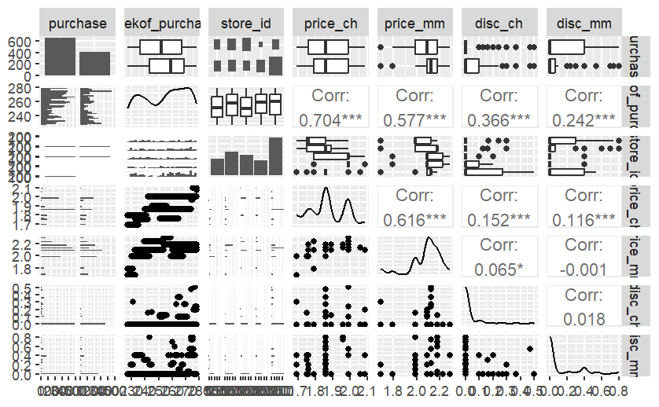

```r
juice_clean %>%
  select(purchase:disc_mm) %>%
  ggpairs()
```

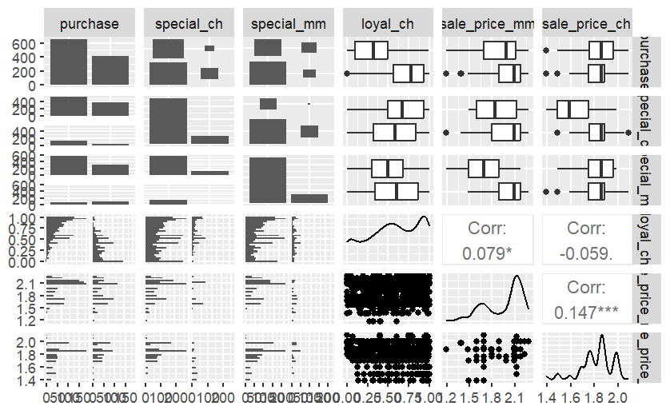

```r
juice_clean %>%
  select(purchase,special_ch:sale_price_ch) %>%
  ggpairs()
```

From split 1, there are relationships between purchase and price_mm and price_ch, possibly with week of purchase and store_id too.

From split 2, there are relationships between sale_price_ch and sale_price_mm, and loyal_ch, possibly with special_ch and special_mm too.

## Logistic Regression

```r
mod_1a <- glm(purchase ~ price_mm, data = juice_clean, family = binomial(link = 'logit'))

mod_1b<- glm(purchase ~ price_ch, data = juice_clean, family = binomial(link = 'logit'))

mod_1c <- glm(purchase ~ weekof_purchase, data = juice_clean, family = binomial(link = 'logit'))

mod_1d <- glm(purchase ~ store_id, data = juice_clean, family = binomial(link = 'logit'))

#mod_1e <- glm(purchase ~ price_mm, data = juice_clean, family = binomial(link = 'logit')) extra model accidentally created!

mod_1f <- glm(purchase ~ sale_price_mm, data = juice_clean, family = binomial(link = 'logit'))

mod_1g <- glm(purchase ~ sale_price_ch, data = juice_clean, family = binomial(link = 'logit'))

mod_1h <- glm(purchase ~ loyal_ch, data = juice_clean, family = binomial(link = 'logit'))

mod_1i <- glm(purchase ~ special_ch, data = juice_clean, family = binomial(link = 'logit'))

mod_1j <- glm(purchase ~ special_mm, data = juice_clean, family = binomial(link = 'logit'))



clean_names(tidy(mod_1a))
```

| term | estimate | std_error | statistic | p_value |
| --- | --- | --- | --- | --- |
| (Intercept) | 4.244995 | 0.9818864 | 4.323306 | 1.537085e-05 |
| price_mm | -2.253920 | 0.4708867 | -4.786545 | 1.696768e-06 |

```r
clean_names(tidy(mod_1b))
```

| term | estimate | std_error | statistic | p_value |
| --- | --- | --- | --- | --- |
| (Intercept) | 0.4167810 | 1.1506674 | 0.3622081 | 0.7171966 |
| price_ch | -0.4634834 | 0.6156155 | -0.7528780 | 0.4515232 |

```r
clean_names(tidy(mod_1c))
```

| term | estimate | std_error | statistic | p_value |
| --- | --- | --- | --- | --- |
| (Intercept) | 3.77225365 | 1.032830317 | 3.652346 | 2.598555e-04 |
| weekof_purchase | -0.01662007 | 0.004065917 | -4.087655 | 4.357552e-05 |

```r
clean_names(tidy(mod_1d))
```

| term | estimate | std_error | statistic | p_value |
| --- | --- | --- | --- | --- |
| (Intercept) | -0.1659851 | 0.1601674 | -1.036323 | 3.000515e-01 |
| store_id2 | 0.2380884 | 0.2090336 | 1.138996 | 2.547048e-01 |
| store_id3 | 0.6442876 | 0.2173738 | 2.963961 | 3.037070e-03 |
| store_id4 | -1.2566769 | 0.2676176 | -4.695793 | 2.655747e-06 |
| store_id7 | -1.0404237 | 0.2037114 | -5.107342 | 3.267220e-07 |

```r
clean_names(tidy(mod_1e))
```

| term | estimate | std_error | statistic | p_value |
| --- | --- | --- | --- | --- |
| (Intercept) | 4.244995 | 0.9818864 | 4.323306 | 1.537085e-05 |
| price_mm | -2.253920 | 0.4708867 | -4.786545 | 1.696768e-06 |

```r
clean_names(tidy(mod_1f))
```

| term | estimate | std_error | statistic | p_value |
| --- | --- | --- | --- | --- |
| (Intercept) | 3.055783 | 0.4981496 | 6.134267 | 8.555253e-10 |
| sale_price_mm | -1.794702 | 0.2538166 | -7.070860 | 1.539768e-12 |

```r
clean_names(tidy(mod_1g))
```

| term | estimate | std_error | statistic | p_value |
| --- | --- | --- | --- | --- |
| (Intercept) | -4.077826 | 0.8544263 | -4.772590 | 1.818722e-06 |
| sale_price_ch | 1.993373 | 0.4665668 | 4.272427 | 1.933568e-05 |

```r
clean_names(tidy(mod_1h))
```

| term | estimate | std_error | statistic | p_value |
| --- | --- | --- | --- | --- |
| (Intercept) | 2.755397 | 0.1995901 | 13.80528 | 2.368569e-43 |
| loyal_ch | -6.094763 | 0.3611485 | -16.87606 | 6.750426e-64 |

```r
clean_names(tidy(mod_1i))
```

| term | estimate | std_error | statistic | p_value |
| --- | --- | --- | --- | --- |
| (Intercept) | -0.3364722 | 0.06716605 | -5.009558 | 5.455511e-07 |
| special_chTRUE | -0.8484004 | 0.19950617 | -4.252502 | 2.113954e-05 |

```r
clean_names(tidy(mod_1j))
```

| term | estimate | std_error | statistic | p_value |
| --- | --- | --- | --- | --- |
| (Intercept) | -0.6090085 | 0.06989797 | -8.712821 | 2.964036e-18 |
| special_mmTRUE | 0.9474629 | 0.16933873 | 5.595075 | 2.205261e-08 |

```r
NA
NA
```

### ROC Curves

```r
mod_1a_pred <- juice_clean %>%
  add_predictions(mod_1a, type = "response")
mod_1c_pred <- juice_clean %>%
  add_predictions(mod_1c, type = "response")
mod_1e_pred <- juice_clean %>%
  add_predictions(mod_1e, type = "response")
mod_1f_pred <- juice_clean %>%
  add_predictions(mod_1f, type = "response")
mod_1g_pred <- juice_clean %>%
  add_predictions(mod_1g, type = "response")
mod_1h_pred <- juice_clean %>%
  add_predictions(mod_1h, type = "response")
mod_1i_pred <- juice_clean %>%
  add_predictions(mod_1i, type = "response")

roc_mod_1a <- mod_1a_pred %>%
  roc(response = purchase, predictor = pred)
roc_mod_1c <- mod_1c_pred %>%
  roc(response = purchase, predictor = pred)
roc_mod_1e <- mod_1e_pred %>%
  roc(response = purchase, predictor = pred)
roc_mod_1f <- mod_1f_pred %>%
  roc(response = purchase, predictor = pred)
roc_mod_1g <- mod_1g_pred %>%
  roc(response = purchase, predictor = pred)
roc_mod_1h <- mod_1h_pred %>%
  roc(response = purchase, predictor = pred)
roc_mod_1i <- mod_1i_pred %>%
  roc(response = purchase, predictor = pred)
```

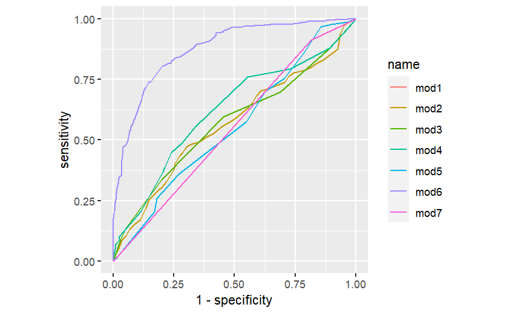

```r
roc_curve <- ggroc(data = list(mod1 = roc_mod_1a,
                               mod2 = roc_mod_1c,
                               mod3 = roc_mod_1e,
                               mod4 = roc_mod_1f,
                               mod5 = roc_mod_1g,
                               mod6 = roc_mod_1h,
                               mod7 = roc_mod_1i),
                   legacy.axes = TRUE) +
  coord_fixed()

roc_curve
```

It looks like mod6 (mod_1h, “loyal_ch”) will be the best classifier as its curve gets closest to the top left corner and it is above the diagonal line. mod4 (mod_1f, “sale_price_mm”) is probably the second best classifier as it is next closest to the line.

```r
auc(roc_mod_1a)
```

```
Area under the curve: 0.57
```

```r
auc(roc_mod_1c)
```

```
Area under the curve: 0.5662
```

```r
auc(roc_mod_1e)
```

```
Area under the curve: 0.57
```

```r
auc(roc_mod_1f)
```

```
Area under the curve: 0.6198
```

```r
auc(roc_mod_1g)
```

```
Area under the curve: 0.555
```

```r
auc(roc_mod_1h)
```

```
Area under the curve: 0.874
```

```r
auc(roc_mod_1i)
```

```
Area under the curve: 0.5483
```

The AUC for mod_1h (loyal_ch) is highest, confirming that it is the best predictor. Mod_1f (sale_price_mm) is also confirmed as the second best predictor as it’s AUC value is second highest.

**Adding sale_price_mm to the model:**

```r
(mod_2a <- glm(purchase ~ loyal_ch + sale_price_mm, data = juice_clean, family = binomial(link = "logit"))
)
```

```
Call:  glm(formula = purchase ~ loyal_ch + sale_price_mm, family = binomial(link = "logit"),
    data = juice_clean)

Coefficients:
  (Intercept)       loyal_ch  sale_price_mm
        7.189         -6.223         -2.261

Degrees of Freedom: 1069 Total (i.e. Null);  1067 Residual
Null Deviance:      1431
Residual Deviance: 871.7    AIC: 877.7
```

```r
clean_names(tidy(mod_2a))
```

| term | estimate | std_error | statistic | p_value |
| --- | --- | --- | --- | --- |
| (Intercept) | 7.188767 | 0.7080294 | 10.153204 | 3.206605e-24 |
| loyal_ch | -6.222740 | 0.3714947 | -16.750547 | 5.610812e-63 |
| sale_price_mm | -2.261261 | 0.3344252 | -6.761635 | 1.364430e-11 |

sale_price_mm has a low p value so is significant.

**How does the model look with all predictors added, in order of AUC score?**

```r
(mod_2b <- glm(purchase ~ loyal_ch + sale_price_mm + price_mm + weekof_purchase + sale_price_ch + special_ch, data = juice_clean, family = binomial(link = "logit"))
)
```

```
Call:  glm(formula = purchase ~ loyal_ch + sale_price_mm + price_mm +
    weekof_purchase + sale_price_ch + special_ch, family = binomial(link = "logit"),
    data = juice_clean)

Coefficients:
    (Intercept)         loyal_ch    sale_price_mm         price_mm
       2.905196        -6.358292        -2.504434        -0.973618
weekof_purchase    sale_price_ch   special_chTRUE
      -0.001141         3.945528        -0.217568

Degrees of Freedom: 1069 Total (i.e. Null);  1063 Residual
Null Deviance:      1431
Residual Deviance: 835.1    AIC: 849.1
```

```r
clean_names(tidy(mod_2b))
```

| term | estimate | std_error | statistic | p_value |
| --- | --- | --- | --- | --- |
| (Intercept) | 2.905196006 | 1.674550691 | 1.7349108 | 8.275661e-02 |
| loyal_ch | -6.358291636 | 0.391763896 | -16.2299071 | 3.099281e-59 |
| sale_price_mm | -2.504433666 | 0.450820268 | -5.5552819 | 2.771641e-08 |
| price_mm | -0.973618434 | 1.018264638 | -0.9561546 | 3.389941e-01 |
| weekof_purchase | -0.001140893 | 0.007320577 | -0.1558474 | 8.761533e-01 |
| sale_price_ch | 3.945528187 | 0.858592684 | 4.5953434 | 4.320373e-06 |
| special_chTRUE | -0.217568196 | 0.301239111 | -0.7222442 | 4.701444e-01 |

1,4,5,7 price_mm, weekof_purchase, and special_ch have high p values for a significance level of 0.05, so these should be removed from the model.

```r
(mod_2c <- glm(purchase ~ loyal_ch + sale_price_mm  + sale_price_ch, data = juice_clean, family = binomial(link = "logit"))
)
```

```
Call:  glm(formula = purchase ~ loyal_ch + sale_price_mm + sale_price_ch,
    family = binomial(link = "logit"), data = juice_clean)

Coefficients:
  (Intercept)       loyal_ch  sale_price_mm  sale_price_ch
        1.448         -6.426         -2.715          3.707

Degrees of Freedom: 1069 Total (i.e. Null);  1066 Residual
Null Deviance:      1431
Residual Deviance: 838.1    AIC: 846.1
```

```r
clean_names(tidy(mod_2c))
```

| term | estimate | std_error | statistic | p_value |
| --- | --- | --- | --- | --- |
| (Intercept) | 1.448388 | 1.2302201 | 1.177340 | 2.390598e-01 |
| loyal_ch | -6.426130 | 0.3884228 | -16.544162 | 1.764023e-61 |
| sale_price_mm | -2.714625 | 0.3573079 | -7.597441 | 3.020445e-14 |
| sale_price_ch | 3.706904 | 0.6706020 | 5.527726 | 3.244079e-08 |

The p values are all significant now.

**Compare mod_1h (loyal_ch only) with mod_2a(loyal_ch and sale_price_mm) and mod_2c (loyal_ch with sale_price_mm and sale_price_ch)**

```r
mod_1h
```

```
Call:  glm(formula = purchase ~ loyal_ch, family = binomial(link = "logit"),
    data = juice_clean)

Coefficients:
(Intercept)     loyal_ch
      2.755       -6.095

Degrees of Freedom: 1069 Total (i.e. Null);  1068 Residual
Null Deviance:      1431
Residual Deviance: 920.6    AIC: 924.6
```

```r
mod_2a
```

```
Call:  glm(formula = purchase ~ loyal_ch + sale_price_mm, family = binomial(link = "logit"),
    data = juice_clean)

Coefficients:
  (Intercept)       loyal_ch  sale_price_mm
        7.189         -6.223         -2.261

Degrees of Freedom: 1069 Total (i.e. Null);  1067 Residual
Null Deviance:      1431
Residual Deviance: 871.7    AIC: 877.7
```

```r
mod_2c
```

```
Call:  glm(formula = purchase ~ loyal_ch + sale_price_mm + sale_price_ch,
    family = binomial(link = "logit"), data = juice_clean)

Coefficients:
  (Intercept)       loyal_ch  sale_price_mm  sale_price_ch
        1.448         -6.426         -2.715          3.707

Degrees of Freedom: 1069 Total (i.e. Null);  1066 Residual
Null Deviance:      1431
Residual Deviance: 838.1    AIC: 846.1
```

Lower AIC models indicate a better fit model, so that would mean mod_2c is the best fit model.

**compare models using ROC and AUC**

```r
mod_1h_pred <- juice_clean %>%
  add_predictions(mod_1h, type = "response")
mod_2a_pred <- juice_clean %>%
  add_predictions(mod_2a, type = "response")
mod_2c_pred <- juice_clean %>%
  add_predictions(mod_2c, type = "response")


roc_mod_1h <- mod_1h_pred %>%
  roc(response = purchase, predictor = pred)
roc_mod_2a <- mod_2a_pred %>%
  roc(response = purchase, predictor = pred)
roc_mod_2c <- mod_2c_pred %>%
  roc(response = purchase, predictor = pred)
```

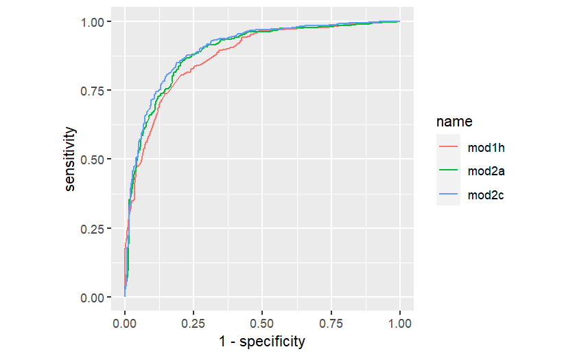

```r
roc_curve_2 <- ggroc(data = list(mod1h = roc_mod_1h,
                               mod2a = roc_mod_2a,
                               mod2c = roc_mod_2c),
                   legacy.axes = TRUE) +
  coord_fixed()

roc_curve_2
```

All models look fairly similar, and all look like they are good predictors as they are all curved nicely near the top left hand corner. Mod_2c is possibly marginally better.

```r
auc(roc_mod_1h)
```

```
Area under the curve: 0.874
```

```r
auc(roc_mod_2a)
```

```
Area under the curve: 0.8895
```

```r
auc(roc_mod_2c)
```

```
Area under the curve: 0.8995
```

The AUC confirms the ROC suggestions that the models are all similar, with mod_2c being marginally better.

## Evaluating the model

```r
juice_clean
```

| purchase | weekof_purchase | store_id | price_ch | price_mm | disc_ch | disc_mm | special_ch | special_mm | loyal_ch | sale_price_mm | sale_price_ch |
| --- | --- | --- | --- | --- | --- | --- | --- | --- | --- | --- | --- |
| FALSE | 237 | 1 | 1.75 | 1.99 | 0.00 | 0.00 | FALSE | FALSE | 0.500000 | 1.99 | 1.75 |
| FALSE | 239 | 1 | 1.75 | 1.99 | 0.00 | 0.30 | FALSE | TRUE | 0.600000 | 1.69 | 1.75 |
| FALSE | 245 | 1 | 1.86 | 2.09 | 0.17 | 0.00 | FALSE | FALSE | 0.680000 | 2.09 | 1.69 |
| TRUE | 227 | 1 | 1.69 | 1.69 | 0.00 | 0.00 | FALSE | FALSE | 0.400000 | 1.69 | 1.69 |
| FALSE | 228 | 7 | 1.69 | 1.69 | 0.00 | 0.00 | FALSE | FALSE | 0.956535 | 1.69 | 1.69 |
| FALSE | 230 | 7 | 1.69 | 1.99 | 0.00 | 0.00 | FALSE | TRUE | 0.965228 | 1.99 | 1.69 |
| FALSE | 232 | 7 | 1.69 | 1.99 | 0.00 | 0.40 | TRUE | TRUE | 0.972182 | 1.59 | 1.69 |
| FALSE | 234 | 7 | 1.75 | 1.99 | 0.00 | 0.40 | TRUE | FALSE | 0.977746 | 1.59 | 1.75 |
| FALSE | 235 | 7 | 1.75 | 1.99 | 0.00 | 0.40 | FALSE | FALSE | 0.982197 | 1.59 | 1.75 |
| FALSE | 238 | 7 | 1.75 | 1.99 | 0.00 | 0.40 | FALSE | FALSE | 0.985757 | 1.59 | 1.75 |

[output cut: 990 more lines]

The `purchase` and `special_ch/mm` columns will need to be transformed to factors, and `purchase` will need to be recoding from 0/1 to CH/MM

```r
(juice_clean_factor <- juice_clean %>%
  mutate(purchase = as.factor(if_else(purchase == "FALSE", "CH", "MM")),
         special_ch = as.factor(special_ch),
         special_mm = as.factor(special_mm)
         )
)
```

| purchase | weekof_purchase | store_id | price_ch | price_mm | disc_ch | disc_mm | special_ch | special_mm | loyal_ch | sale_price_mm | sale_price_ch |
| --- | --- | --- | --- | --- | --- | --- | --- | --- | --- | --- | --- |
| CH | 237 | 1 | 1.75 | 1.99 | 0.00 | 0.00 | FALSE | FALSE | 0.500000 | 1.99 | 1.75 |
| CH | 239 | 1 | 1.75 | 1.99 | 0.00 | 0.30 | FALSE | TRUE | 0.600000 | 1.69 | 1.75 |
| CH | 245 | 1 | 1.86 | 2.09 | 0.17 | 0.00 | FALSE | FALSE | 0.680000 | 2.09 | 1.69 |
| MM | 227 | 1 | 1.69 | 1.69 | 0.00 | 0.00 | FALSE | FALSE | 0.400000 | 1.69 | 1.69 |
| CH | 228 | 7 | 1.69 | 1.69 | 0.00 | 0.00 | FALSE | FALSE | 0.956535 | 1.69 | 1.69 |
| CH | 230 | 7 | 1.69 | 1.99 | 0.00 | 0.00 | FALSE | TRUE | 0.965228 | 1.99 | 1.69 |
| CH | 232 | 7 | 1.69 | 1.99 | 0.00 | 0.40 | TRUE | TRUE | 0.972182 | 1.59 | 1.69 |
| CH | 234 | 7 | 1.75 | 1.99 | 0.00 | 0.40 | TRUE | FALSE | 0.977746 | 1.59 | 1.75 |
| CH | 235 | 7 | 1.75 | 1.99 | 0.00 | 0.40 | FALSE | FALSE | 0.982197 | 1.59 | 1.75 |
| CH | 238 | 7 | 1.75 | 1.99 | 0.00 | 0.40 | FALSE | FALSE | 0.985757 | 1.59 | 1.75 |

[output cut: 990 more lines]

```r
train_control <- trainControl(method = "repeatedcv",
                              number = 5,
                              repeats = 100,
                              savePredictions = TRUE,
                              classProbs = TRUE,
                              summaryFunction = twoClassSummary)
```

```r
mod_2c_cv <- train(mod_2c$formula,
                   data = juice_clean_factor,
                   trControl = train_control,
                   method = "glm",
                   family = binomial(link = "logit"))
```

```r
summary(mod_2c_cv)
```

```
Call:
NULL

Coefficients:
              Estimate Std. Error z value Pr(>|z|)
(Intercept)     1.4484     1.2302   1.177    0.239
loyal_ch       -6.4261     0.3884 -16.544  < 2e-16 ***
sale_price_mm  -2.7146     0.3573  -7.597 3.02e-14 ***
sale_price_ch   3.7069     0.6706   5.528 3.24e-08 ***
---
Signif. codes:  0 ‘***’ 0.001 ‘**’ 0.01 ‘*’ 0.05 ‘.’ 0.1 ‘ ’ 1

(Dispersion parameter for binomial family taken to be 1)

    Null deviance: 1430.85  on 1069  degrees of freedom
Residual deviance:  838.11  on 1066  degrees of freedom
AIC: 846.11

Number of Fisher Scoring iterations: 5
```

[output not shown]

The actual AUC value was 0.8995, so this is very close to this value of 0.8981. Mod_2c is a well performing model! The predictors were:

purchase ~ loyal_ch + sale_price_mm + sale_price_ch = Customer Loyalty + sale price of Minute Maid + sale price Citrus Hill